# Quantity Controls

October 12, 2018

## Pregame

- [Slides on climate and agriculture](https://potterzot.com/research/climateImpact/agImpact_NWCC2018.html) that I presented at the conference this week.
- [This article](http://www.anderson.ucla.edu/faculty-and-research/anderson-review/minimum-wage-primer-leamer) on the minimum wage does a good job of explaining the long debate and difficult process of trying to test whether the minimum wage actually leads to less employment or not.
- [This youtuber](https://www.youtube.com/watch?v=uCZ58OJjrFU) explains quotas while wearing a jedi costume (though he also is talking about trade, which we haven’t gotten to yet).

## Feedback

### Good:

- Thought the guest speaker explained the concepts well

### Needs improvement:

- The consumer surplus and producer surplus is still kind of confusing.

## Catching up on price controls

- **Price Floor** - A minimum price at which a product can be sold. Typically this is applied by purchasing excess supply (driving up the price to the set price floor).

## Effect of a price floor

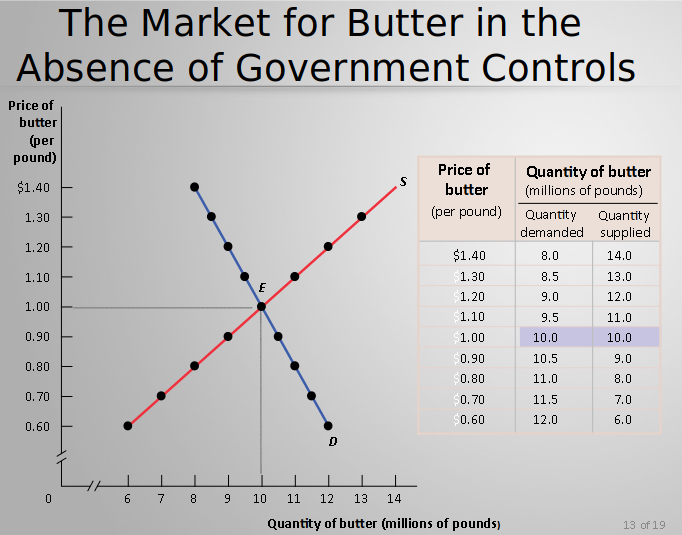

## Effect of a price floor

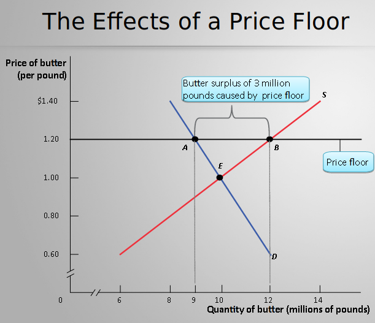

## Why a Price Floor?

- Society values an industry and is willing to pay to support it even if it is not profitable.
- An industry is politically powerful and can lobby for price supports.

## Quotas

- **Quantity Controls / Quotas** - A **Quota** is a government limit on the amount of a product that can be produced. This is typically done by allowing only licensed producers to produce, and in limited amount.

E.g., licenses to operate a business do the same thing. Liquor licenses, bar licenses, doctor and lawyer licensing, etc…

## Effect of a quota

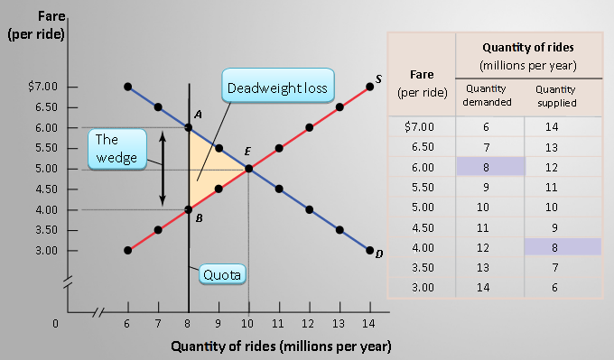

## Why a Quota?

- Protect renewable resources from over-extraction.
- Limit imports from other countries or from competing industries.
- Restrict competition from other firms.

## Licensing dilemma’s

Who should be licensed?

- Hairdressers?
- Pet sitters?
- Childcare providers?
- Plumbers?
- Electricians?
- Lawyers?
- Doctors?

## Wrapping Up

- Complete the [knowledge check](https://goo.gl/forms/daWlbF0C0fBRhcWn2) for today’s participation point.
- Please provide [feedback](https://goo.gl/forms/8SiOwdi19kN8cINJ3) on today’s lecture.